# Web log analysis

QUAN YU

## 1. Introduction

These data comes from a Czech company running several internet shops. The log data cover the traffic on the web server of about three weeks. This represents about 3 mil. records (each record is a single page view). The stored data allow to derive the products (the internet shop is oriented on electronics), type of page (such as shopping cart or detail of product), and internet shop (this info has been anonymised).

A generated ID is contained in the records, so identifying sessions (click-streams of single user) is easy. Details please see http://lisp.vse.cz/challenge/CURRENT/.

## 2. Preprocess

```r
library(arules)
library(arulesViz)
library(data.table)
library(knitr)
```

```r
# each text file is generated from a clickstream directory
a1 = fread("clickstream1.txt")
a2 = fread("clickstream2.txt")
a3 = fread("clickstream3.txt")
a4 = fread("clickstream4.txt")
data = rbindlist(list(a1, a2, a3, a4))
dim(data)
```

```
## [1] 352375      5
```

```r
# kable(data[1:10])
data
```

| unix_time | sessionID | ProductCate | ProductBrand | pageType |
| --- | --- | --- | --- | --- |
| 1074596771 | 00092c0020323ba158f11d595cc04198 | 150 | null | ct |
| 1074596790 | 00092c0020323ba158f11d595cc04198 | 147 | null | ct |
| 1074607939 | 0017ebbfc1961370a4bee0a31d6bb773 | 162 | null | ct |
| 1074609590 | 0017ebbfc1961370a4bee0a31d6bb773 | 168 | null | ct |
| 1074609690 | 0017ebbfc1961370a4bee0a31d6bb773 | null | null | kosik |
| 1074609691 | 0017ebbfc1961370a4bee0a31d6bb773 | null | null | kosik |
| 1074609769 | 0017ebbfc1961370a4bee0a31d6bb773 | null | null | kosik |
| 1074609780 | 0017ebbfc1961370a4bee0a31d6bb773 | null | null | kosik |
| 1074609796 | 0017ebbfc1961370a4bee0a31d6bb773 | null | null | kosik |
| 1074609817 | 0017ebbfc1961370a4bee0a31d6bb773 | null | null | kosik |

[output cut: 40 more lines]

```r
preprocess <- function(train) {
  x = train[,2:5]
  xu <- x[!duplicated(x),]
  xu$item[xu$ProductBrand != "null"] = paste0("b=", xu$ProductBrand[xu$ProductBrand != "null"])
  xu$item[xu$ProductCate != "null"] = paste0("c=", xu$ProductCate[xu$ProductCate != "null"])
  xu$item[xu$pageType == "kosik"] = "shop"
  out = na.omit(xu)[, c(1,5)]
  return(out)
}

# data is the transaction format we need
# sort(unique(data$item))  # any na?
data = preprocess(data)
dim(data)
```

```
## [1] 225199      2
```

```r
data
```

| sessionID | item |
| --- | --- |
| 00092c0020323ba158f11d595cc04198 | c=150 |
| 00092c0020323ba158f11d595cc04198 | c=147 |
| 0017ebbfc1961370a4bee0a31d6bb773 | c=162 |
| 0017ebbfc1961370a4bee0a31d6bb773 | c=168 |
| 0017ebbfc1961370a4bee0a31d6bb773 | shop |
| 00191e8e5ebf47a54c3e709e35866b81 | c=388 |
| 002f4b38e5863bed79a1e491b75829ad | c=141 |
| 0031877ce5e977c08227de13ec65ce9e | c=141 |
| 0035599d8d7ada51540f21b7c04c9c43 | c=141 |
| 0039acc4c7f5b23cba5009115e2cec8b | c=156 |

[output cut: 40 more lines]

Now we split data into train/validation/test subsets with ratio 6/2/2.

```r
sid = unique(data$sessionID)
# split sid
set.seed(100)
idx = sample.int(5, length(sid), replace = T)
train_sid = sid[which(idx >= 3)]
valid_sid = sid[which(idx == 1)]
test_sid  = sid[which(idx == 2)]
cat(length(train_sid), length(valid_sid), length(test_sid))
```

```
## 90499 30246 30545
```

```r
train = as.data.frame(data[sessionID %in% train_sid])
valid = as.data.frame(data[sessionID %in% valid_sid])
test  = as.data.frame(data[sessionID %in% test_sid])
cat(nrow(train), nrow(valid), nrow(test))
```

```
## 134852 44876 45471
```

```r
# remove shop
train_sub1 = subset(train, item != "shop")
# remove product categories
train_sub2 = train[-grep("c=", train$item),]
# remove brands
train_sub3 = train[-grep("b=", train$item),]

trainegs <- as(split(train_sub1[,"item"], train_sub1[,"sessionID"]), "transactions")
summary(trainegs)
```

```
## transactions as itemMatrix in sparse format with
##  87059 rows (elements/itemsets/transactions) and
##  274 columns (items) and a density of 0.005426474
##
## most frequent items:
##   c=141   c=153   c=164   c=155   c=161 (Other)
##   15694    5810    5720    4964    4959   92297
##
## element (itemset/transaction) length distribution:
## sizes
##     1     2     3     4     5     6     7     8     9    10    11    12    13    14    15    16    17    18    19    20
## 62519 15819  4999  1931   848   425   195    98    59    40    30    12     7     8    12     5     2     8     6     1
##    22    23    25    26    28    29    35    38    48    49    50    52    93    94   120
##     1     5     3    10     1     1     1     1     1     2     2     2     1     3     1
##
##    Min. 1st Qu.  Median    Mean 3rd Qu.    Max.
##   1.000   1.000   1.000   1.487   2.000 120.000
##
## includes extended item information - examples:
##   labels
## 1    b=1
## 2   b=10
## 3  b=100
##
## includes extended transaction information - examples:
##                      transactionID
## 1 00000bed1f060eee61482dd61a689c2f
## 2 0000b5a84e1844fda5b6b6ad994f6865
## 3 0001a4246d316ed6fc12ffb2b64f86af
```

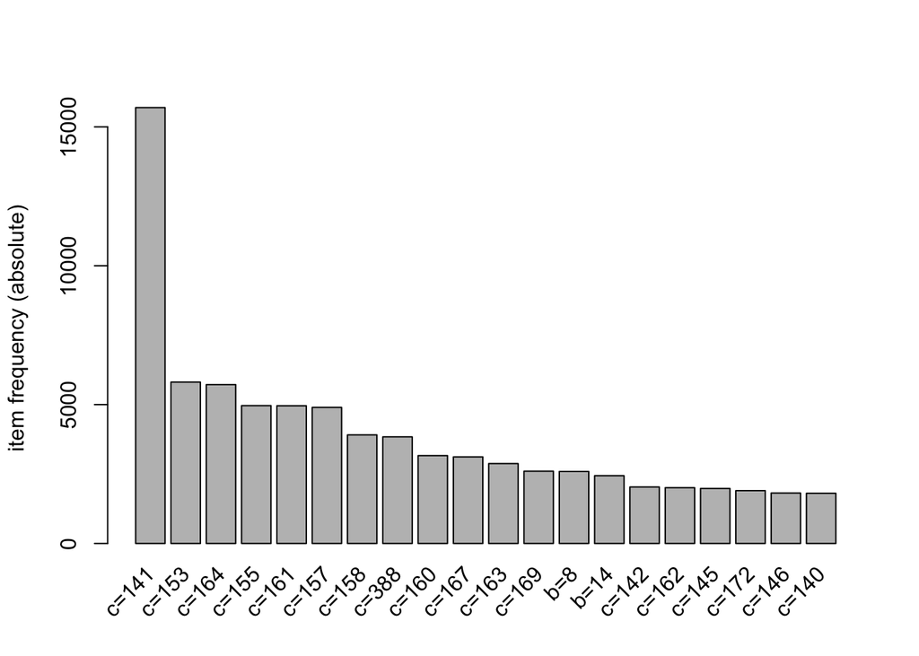

```r
itemFrequencyPlot(trainegs,topN=20,type="absolute")
```

```r
traineg2 <- as(split(train_sub2[,"item"], train_sub2[,"sessionID"]), "transactions")
summary(traineg2)
```

```
## transactions as itemMatrix in sparse format with
##  27622 rows (elements/itemsets/transactions) and
##  188 columns (items) and a density of 0.006060541
##
## most frequent items:
##    shop     b=8    b=14    b=39    b=22 (Other)
##    5408    2592    2440    1244     906   18882
##
## element (itemset/transaction) length distribution:
## sizes
##     1     2     3     4     5     6     7     8     9    10    11    12    13    14    15    16    18    19    20    22
## 26053  1085   220    76    61    23    17    10    12     8     7     2     6     2     5     4     2     1     1     1
##    23    24    25    26    27    38    39    40    41    46    52    68    83
##     3     2     3     3     2     2     2     1     1     1     1     4     1
##
##    Min. 1st Qu.  Median    Mean 3rd Qu.    Max.
##   1.000   1.000   1.000   1.139   1.000  83.000
##
## includes extended item information - examples:
##   labels
## 1    b=1
## 2   b=10
## 3  b=100
##
## includes extended transaction information - examples:
##                      transactionID
## 1 0000b5a84e1844fda5b6b6ad994f6865
## 2 0004bf441e1e84a7db4d89284020df08
## 3 00053f1caded9fa85b7ae32ca7baf000
```

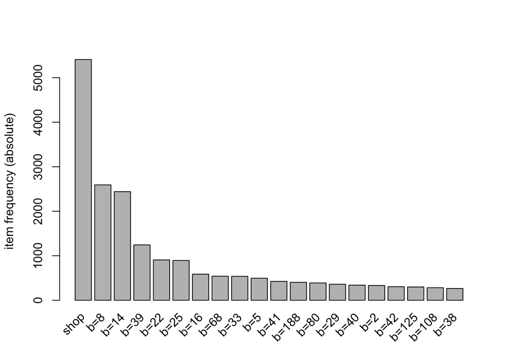

```r
itemFrequencyPlot(traineg2,topN=20,type="absolute")
```

```r
traineg3 <- as(split(train_sub3[,"item"], train_sub3[,"sessionID"]), "transactions")
```

Please note that items with “c=” are product categories, “b=” are brands and “shop” are the shopping cart.

## 3. Association rules

### Product category and brands

```r
rules <- apriori(trainegs, parameter = list(supp=0.001, conf=0.5, minlen=2, maxlen=2))
```

```
## Apriori
##
## Parameter specification:
##  confidence minval smax arem  aval originalSupport maxtime support minlen maxlen target   ext
##         0.5    0.1    1 none FALSE            TRUE       5   0.001      2      2  rules FALSE
##
## Algorithmic control:
##  filter tree heap memopt load sort verbose
##     0.1 TRUE TRUE  FALSE TRUE    2    TRUE
##
## Absolute minimum support count: 87
##
## set item appearances ...[0 item(s)] done [0.00s].
## set transactions ...[274 item(s), 87059 transaction(s)] done [0.01s].
## sorting and recoding items ... [131 item(s)] done [0.00s].
## creating transaction tree ... done [0.02s].
## checking subsets of size 1 2
```

```
##  done [0.00s].
## writing ... [9 rule(s)] done [0.00s].
## creating S4 object  ... done [0.01s].
```

```r
summary(rules)
```

```
## set of 9 rules
##
## rule length distribution (lhs + rhs):sizes
## 2
## 9
##
##    Min. 1st Qu.  Median    Mean 3rd Qu.    Max.
##       2       2       2       2       2       2
##
## summary of quality measures:
##     support           confidence          lift            count
##  Min.   :0.001332   Min.   :0.5297   Min.   : 2.947   Min.   : 116.0
##  1st Qu.:0.002964   1st Qu.:0.5377   1st Qu.: 3.454   1st Qu.: 258.0
##  Median :0.005674   Median :0.5704   Median : 8.548   Median : 494.0
##  Mean   :0.006940   Mean   :0.5787   Mean   : 9.191   Mean   : 604.2
##  3rd Qu.:0.010326   3rd Qu.:0.6226   3rd Qu.:12.012   3rd Qu.: 899.0
##  Max.   :0.014553   Max.   :0.6580   Max.   :23.250   Max.   :1267.0
##
## mining info:
##      data ntransactions support confidence
##  trainegs         87059   0.001        0.5
```

```r
inspect(head(rules, n = 9, by = "confidence"))
```

```
##     lhs        rhs     support     confidence lift      count
## [1] {c=170} => {c=164} 0.007293904 0.6580311  10.015302  635
## [2] {c=145} => {c=141} 0.014426998 0.6340232   3.517104 1256
## [3] {c=142} => {c=141} 0.014553349 0.6226044   3.453761 1267
## [4] {c=159} => {c=160} 0.002963508 0.5810811  15.988729  258
## [5] {c=457} => {c=153} 0.005674313 0.5704388   8.547647  494
## [6] {c=143} => {c=142} 0.002871616 0.5434783  23.250454  250
## [7] {c=144} => {c=141} 0.010326330 0.5376794   2.982658  899
## [8] {b=5}   => {c=141} 0.003020940 0.5313131   2.947342  263
## [9] {b=105} => {c=388} 0.001332430 0.5296804  12.011837  116
```

### Brands and shopping cart

```r
rules2 <- apriori(traineg2, parameter = list(supp=0.001, conf=0.01, minlen=2))
```

```
## Apriori
##
## Parameter specification:
##  confidence minval smax arem  aval originalSupport maxtime support minlen maxlen target   ext
##        0.01    0.1    1 none FALSE            TRUE       5   0.001      2     10  rules FALSE
##
## Algorithmic control:
##  filter tree heap memopt load sort verbose
##     0.1 TRUE TRUE  FALSE TRUE    2    TRUE
##
## Absolute minimum support count: 27
##
## set item appearances ...[0 item(s)] done [0.00s].
## set transactions ...[188 item(s), 27622 transaction(s)] done [0.00s].
## sorting and recoding items ... [153 item(s)] done [0.00s].
## creating transaction tree ... done [0.00s].
## checking subsets of size 1 2 3 4 done [0.00s].
## writing ... [98 rule(s)] done [0.00s].
## creating S4 object  ... done [0.00s].
```

```r
inspect(sort(subset(rules2, subset = rhs %in% "shop"), by = "confidence"))
```

```
##     lhs       rhs    support     confidence lift       count
## [1] {b=80} => {shop} 0.001267106 0.08997429 0.45955435 35
## [2] {b=68} => {shop} 0.001267106 0.06469501 0.33043742 35
## [3] {b=22} => {shop} 0.001158497 0.03532009 0.18040153 32
## [4] {b=39} => {shop} 0.001086091 0.02411576 0.12317408 30
## [5] {b=14} => {shop} 0.001122294 0.01270492 0.06489187 31
## [6] {b=8}  => {shop} 0.001049888 0.01118827 0.05714542 29
```

### Product category and shopping cart

```r
rules3 <- apriori(traineg3, parameter = list(supp=0.001, conf=0.01, minlen=2))
```

```
## Apriori
##
## Parameter specification:
##  confidence minval smax arem  aval originalSupport maxtime support minlen maxlen target   ext
##        0.01    0.1    1 none FALSE            TRUE       5   0.001      2     10  rules FALSE
##
## Algorithmic control:
##  filter tree heap memopt load sort verbose
##     0.1 TRUE TRUE  FALSE TRUE    2    TRUE
##
## Absolute minimum support count: 76
##
## set item appearances ...[0 item(s)] done [0.00s].
## set transactions ...[88 item(s), 76425 transaction(s)] done [0.01s].
## sorting and recoding items ... [60 item(s)] done [0.00s].
## creating transaction tree ... done [0.02s].
## checking subsets of size 1 2 3 4 5 done [0.00s].
## writing ... [754 rule(s)] done [0.00s].
## creating S4 object  ... done [0.01s].
```

```r
inspect(sort(subset(rules3, subset = rhs %in% "shop"), by = "confidence"))
```

```
##      lhs              rhs    support     confidence lift      count
## [1]  {c=141,c=145} => {shop} 0.001059863 0.06449045 0.9113688  81
## [2]  {c=166}       => {shop} 0.001138371 0.05559105 0.7856040  87
## [3]  {c=145}       => {shop} 0.001400065 0.05401312 0.7633049 107
## [4]  {c=172}       => {shop} 0.001256133 0.05047319 0.7132791  96
## [5]  {c=161}       => {shop} 0.003218842 0.04960678 0.7010351 246
## [6]  {c=169}       => {shop} 0.001635590 0.04802151 0.6786324 125
## [7]  {c=164}       => {shop} 0.003572130 0.04772727 0.6744743 273
## [8]  {c=162}       => {shop} 0.001243049 0.04728721 0.6682553  95
## [9]  {c=173}       => {shop} 0.001086032 0.04618809 0.6527228  83
## [10] {c=163}       => {shop} 0.001622506 0.04310045 0.6090888 124
## [11] {c=167}       => {shop} 0.001504743 0.03688262 0.5212193 115
## [12] {c=388}       => {shop} 0.001661760 0.03308153 0.4675030 127
## [13] {c=158}       => {shop} 0.001360811 0.02659847 0.3758853 104
## [14] {c=157}       => {shop} 0.001452404 0.02265306 0.3201295 111
## [15] {c=153}       => {shop} 0.001609421 0.02117040 0.2991767 123
## [16] {c=141}       => {shop} 0.004082434 0.01988021 0.2809440 312
## [17] {c=155}       => {shop} 0.001099117 0.01692184 0.2391367  84
```

From the association rules listed above, we found that the associations between brands and shopping cart, and between product category and shopping cart are not reliable. Therefore, we only consider association between product category and brands in the following analysis.

## 4. Make predictions

Define two functions first.

```r
# execute ruleset using item as rule antecedent (handles single item antecedents only)
makepreds <- function(item, rulesDF) {
  antecedent = paste("{",item,"} =>",sep="")
  firingrules = rulesDF[grep(antecedent, rulesDF$rules,fixed=TRUE),1]
  gsub(" ","",toString(sub("\\}","",sub(".*=> \\{","",firingrules))))
}

# compare items bought with predictions
comparepds <- function(items, preds) {
  set1 = strsplit(items, ",")[[1]]
  set2 = strsplit(preds, ",")[[1]]
  n_item = length(set1)
  n_pred = length(set2)
  n_correct = length(intersect(set1, set2))
  list(n_item, n_pred, n_correct)
}
```

Make predictions in the following using validation data.

```r
#execute rules against test data
rulesDF = as(rules,"data.frame")
testegs = valid
colnames(testegs) <- c("basketID","items")
testegs$preds = apply(testegs,1,function(X) makepreds(X["items"], rulesDF))
head(testegs)
```

```
##                           basketID items preds
## 1 002f4b38e5863bed79a1e491b75829ad c=141
## 2 004945bf041d6b524e0577960b1165aa c=505
## 3 00f7da0e2c4d009f7fd719db923c374b c=388
## 4 00f7da0e2c4d009f7fd719db923c374b c=158
## 5 00f7da0e2c4d009f7fd719db923c374b c=157
## 6 019431e0f8c83d5b9741ec8e8dc2e39b c=155
```

```r
# keep only basketIDs with at least one prediction
sid_sub = unique(testegs[testegs$preds != "",]$basketID)
testegs = as.data.table(subset(testegs, basketID %in% sid_sub))
head(testegs)
```

```
##                            basketID items preds
## 1: 034c449d0ea8a9bb0959c611a1eb7f61 c=141
## 2: 034c449d0ea8a9bb0959c611a1eb7f61 c=144 c=141
## 3: 034c449d0ea8a9bb0959c611a1eb7f61 c=145 c=141
## 4: 0400f4d38ef348b69875407d83c428c6 c=170 c=164
## 5: 071cfd3b046c9d792aae8e12a08df1ce c=144 c=141
## 6: 09c2723fa462e83246e413a5b4aa4713 c=141
```

```r
# extract unique items bought and predictions for each test user
userpreds = testegs[,.(items = paste(items, collapse = ","),
                       preds = paste(unique(preds[preds != ""]), collapse = ",")),
                       by = basketID]
head(userpreds)
```

```
##                            basketID                               items preds
## 1: 034c449d0ea8a9bb0959c611a1eb7f61                   c=141,c=144,c=145 c=141
## 2: 0400f4d38ef348b69875407d83c428c6                               c=170 c=164
## 3: 071cfd3b046c9d792aae8e12a08df1ce                               c=144 c=141
## 4: 09c2723fa462e83246e413a5b4aa4713                         c=141,c=144 c=141
## 5: 0b0e82a476a918ce214c4228a16c2641 c=412,c=497,c=161,c=170,c=169,c=506 c=164
## 6: 1037b770f93997627e9d46c410d50fcf                     b=8,c=159,c=160 c=160
```

```r
# count how many items bought, predictions made, and how many predictions are correct
correctpreds = userpreds[, comparepds(items, preds), by = basketID]
head(correctpreds)
```

```
##                            basketID V1 V2 V3
## 1: 034c449d0ea8a9bb0959c611a1eb7f61  3  1  1
## 2: 0400f4d38ef348b69875407d83c428c6  1  1  0
## 3: 071cfd3b046c9d792aae8e12a08df1ce  1  1  0
## 4: 09c2723fa462e83246e413a5b4aa4713  2  1  1
## 5: 0b0e82a476a918ce214c4228a16c2641  6  1  0
## 6: 1037b770f93997627e9d46c410d50fcf  3  1  1
```

```r
# count total number of unique predictions made
result = colSums(correctpreds[, -1])
result
```

```
##   V1   V2   V3
## 6163 2662 1530
```

```r
totalitems = result["V1"]
totalpreds = result["V2"]
totcorrect = result["V3"]

precision = totcorrect*100/totalpreds
recall    = totcorrect*100/totalitems
cat("precision=", precision, "%, recall=", recall, "%, total predictions=", totalpreds)
```

```
## precision= 57.47558 %, recall= 24.82557 %, total predictions= 2662
```

## 5. parameter tunning

We will trying different confidence values and find out which one has the highest accuracy.

```r
rules <- apriori(trainegs, parameter = list(supp=0.001, conf=0.005, minlen=2, maxlen=2))
```

```
## Apriori
##
## Parameter specification:
##  confidence minval smax arem  aval originalSupport maxtime support minlen maxlen target   ext
##       0.005    0.1    1 none FALSE            TRUE       5   0.001      2      2  rules FALSE
##
## Algorithmic control:
##  filter tree heap memopt load sort verbose
##     0.1 TRUE TRUE  FALSE TRUE    2    TRUE
##
## Absolute minimum support count: 87
##
## set item appearances ...[0 item(s)] done [0.00s].
## set transactions ...[274 item(s), 87059 transaction(s)] done [0.01s].
## sorting and recoding items ... [131 item(s)] done [0.00s].
## creating transaction tree ... done [0.02s].
## checking subsets of size 1 2
```

```
##  done [0.00s].
## writing ... [380 rule(s)] done [0.00s].
## creating S4 object  ... done [0.01s].
```

```r
rulesDF = as(rules,"data.frame")
range(rulesDF$confidence)
```

```
## [1] 0.005862113 0.658031088
```

```r
# Define a function that measures the overall performance
performance <- function(conf, supp, dataset){
  rules.sub <- subset(rules, confidence > conf & support > supp)
  n_rules = length(rules.sub)
  subDF = as(rules.sub,"data.frame")
  valid_tmp = dataset
  colnames(valid_tmp) <- c("basketID","items")
  valid_tmp$preds = apply(valid_tmp,1,function(X) makepreds(X["items"], subDF))
  # only consider sessions with a predicted value
  # sid_sub = unique(valid_tmp[valid_tmp$preds != "",]$basketID)
  # tmpegs = as.data.table(subset(valid_tmp, basketID %in% sid_sub))
  tmpegs = as.data.table(valid_tmp)
  userpreds = tmpegs[,.(items = paste(items, collapse = ","),
                       preds = paste(unique(preds[preds != ""]), collapse = ",")),
                       by = basketID]
  correctpreds = userpreds[, comparepds(items, preds), by = basketID]
  result = colSums(correctpreds[, -1])
  totalitems = as.integer(result["V1"])
  totalpreds = as.integer(result["V2"])
  totcorrect = as.integer(result["V3"])
  precision  = totcorrect / totalpreds
  recall     = totcorrect / totalitems
  F1 = 2 * precision * recall / (precision + recall)
  return(data.frame(support = supp, confidence = conf, n_rules, precision, recall, F1, totalpreds, totcorrect))
}
```

F1 score is a measure that combines precision and recall. It is defined as the harmonic mean of precision and recall https://en.wikipedia.org/wiki/Precision_and_recall#F-measure.

```r
# predict in a paralell way
library(foreach)
library(doMC)
registerDoMC(4)
out = foreach(supp = c(0.001, 0.004, 0.007), .combine = rbind) %:%
    foreach(conf = seq(0.05, 0.35, 0.05), .combine = rbind) %dopar% {
    sub = performance(conf, supp, valid)
    sub
}
kable(out)
```

| support | confidence | n_rules | precision | recall | F1 | totalpreds | totcorrect |
| --- | --- | --- | --- | --- | --- | --- | --- |
| 0.001 | 0.05 | 292 | 0.0749743 | 0.3449728 | 0.1231779 | 206484 | 15481 |
| 0.001 | 0.10 | 191 | 0.1158251 | 0.2879936 | 0.1652073 | 111582 | 12924 |
| 0.001 | 0.15 | 103 | 0.1887359 | 0.2086416 | 0.1981902 | 49609 | 9363 |
| 0.001 | 0.20 | 69 | 0.2549622 | 0.1737454 | 0.2066607 | 30581 | 7797 |
| 0.001 | 0.25 | 53 | 0.3116729 | 0.1521972 | 0.2045216 | 21914 | 6830 |
| 0.001 | 0.30 | 40 | 0.3563704 | 0.1277743 | 0.1881048 | 16090 | 5734 |
| 0.001 | 0.35 | 28 | 0.3963112 | 0.0924102 | 0.1498735 | 10464 | 4147 |
| 0.004 | 0.05 | 71 | 0.1267310 | 0.2420670 | 0.1663642 | 85717 | 10863 |
| 0.004 | 0.10 | 63 | 0.1554199 | 0.2132989 | 0.1798167 | 61588 | 9572 |
| 0.004 | 0.15 | 43 | 0.2228506 | 0.1659462 | 0.1902341 | 33417 | 7447 |
| 0.004 | 0.20 | 35 | 0.2691655 | 0.1449773 | 0.1884513 | 24171 | 6506 |
| 0.004 | 0.25 | 28 | 0.3189130 | 0.1294456 | 0.1841467 | 18215 | 5809 |
| 0.004 | 0.30 | 22 | 0.3632915 | 0.1109725 | 0.1700123 | 13708 | 4980 |
| 0.004 | 0.35 | 16 | 0.4006048 | 0.0797085 | 0.1329616 | 8929 | 3577 |
| 0.007 | 0.05 | 27 | 0.1568072 | 0.1481415 | 0.1523513 | 42396 | 6648 |
| 0.007 | 0.10 | 24 | 0.2048300 | 0.1236073 | 0.1541754 | 27081 | 5547 |
| 0.007 | 0.15 | 20 | 0.2426898 | 0.1098583 | 0.1512502 | 20314 | 4930 |
| 0.007 | 0.20 | 16 | 0.3010254 | 0.0955076 | 0.1450080 | 14238 | 4286 |
| 0.007 | 0.25 | 13 | 0.3590858 | 0.0847223 | 0.1370979 | 10588 | 3802 |
| 0.007 | 0.30 | 11 | 0.4043509 | 0.0762100 | 0.1282484 | 8458 | 3420 |
| 0.007 | 0.35 | 8 | 0.4496986 | 0.0531910 | 0.0951299 | 5308 | 2387 |

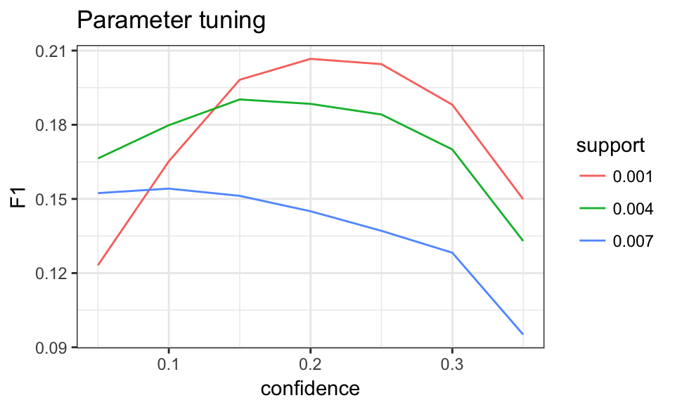

```r
library(ggplot2)
out$support = as.factor(out$support)
ggplot(out, aes(confidence, F1)) + geom_line(aes(colour = support)) +
  ggtitle("Parameter tuning") + theme_bw()
```

```r
  # scale_x_continuous("Support", breaks = c(0.001, 0.004, 0.007))
```

## 6. Final performace

From alove analysis, we never used “test” data for model training or parameter tunning. Here we will use our test data (the held-back dataset) to evaluate the performance of our association rules.

```r
rules.final = sort(subset(rules, confidence > 0.2 & support > 0.001), by="confidence")
as(rules.final, "data.frame")
```

| rules | support | confidence | lift | count |
| --- | --- | --- | --- | --- |
| {c=170} => {c=164} | 0.007293904 | 0.6580311 | 10.015302 | 635 |
| {c=145} => {c=141} | 0.014426998 | 0.6340232 | 3.517104 | 1256 |
| {c=142} => {c=141} | 0.014553349 | 0.6226044 | 3.453761 | 1267 |
| {c=159} => {c=160} | 0.002963508 | 0.5810811 | 15.988729 | 258 |
| {c=457} => {c=153} | 0.005674313 | 0.5704388 | 8.547647 | 494 |
| {c=143} => {c=142} | 0.002871616 | 0.5434783 | 23.250454 | 250 |
| {c=144} => {c=141} | 0.010326330 | 0.5376794 | 2.982658 | 899 |
| {b=5} => {c=141} | 0.003020940 | 0.5313131 | 2.947342 | 263 |
| {b=105} => {c=388} | 0.001332430 | 0.5296804 | 12.011837 | 116 |
| {c=458} => {c=153} | 0.005605394 | 0.4831683 | 7.239957 | 488 |

[output cut: 59 more lines]

```r
# associations between brands and product categories
rules.b2c = subset(rules.final, subset = lhs %pin% "b=")
as(rules.b2c, "data.frame")
```

| rules | support | confidence | lift | count |
| --- | --- | --- | --- | --- |
| {b=5} => {c=141} | 0.003020940 | 0.5313131 | 2.947342 | 263 |
| {b=105} => {c=388} | 0.001332430 | 0.5296804 | 12.011837 | 116 |
| {b=4} => {c=141} | 0.001056755 | 0.4380952 | 2.430237 | 92 |
| {b=42} => {c=164} | 0.001206079 | 0.3442623 | 5.239708 | 105 |
| {b=2} => {c=141} | 0.001252024 | 0.3283133 | 1.821245 | 109 |
| {b=40} => {c=167} | 0.001171619 | 0.3008850 | 8.401136 | 102 |
| {b=29} => {c=161} | 0.001102700 | 0.2666667 | 4.681535 | 96 |

```r
# final performance
kable(performance(0.2, 0.001, test))
```

| support | confidence | n_rules | precision | recall | F1 | totalpreds | totcorrect |
| --- | --- | --- | --- | --- | --- | --- | --- |
| 0.001 | 0.2 | 69 | 0.2531913 | 0.1714279 | 0.2044376 | 30787 | 7795 |

```r
# This is an interactive widget which you can select, drag and zoom in/out.
plot(rules.final, method="graph", engine="htmlwidget")
```

[interactive chart not shown]

## 7. Summary

We identified association rules using training data, and then used validation data to tune the best support and confidence value. At last, we used the held-back testing dataset to measure the performance of our final 69 association rules used that are included in our product recommendation system. These rules generated 30,787 predictive items with 7,795 items correctly predicted. Therefore, the precision of our association model is 0.25 with 0.17 recall, and the overall F1 score is 0.20.